# Week_5_Final

Christophe

July 18, 2015

#### Analysis of hflights data set

This dataset contains all flights departing from Houston airports IAH (George Bush Intercontinental) and HOU (Houston Hobby) in 2011. The data comes from the Research and Innovation Technology Administration at the Bureau of Transporation statistics.

hflights: Flights that departed Houston in 2011

A data only package containing commercial domestic flights that departed Houston (IAH and HOU) in 2011.

Version: 0.1  
Depends: R (??? 2.10)  
Published: 2013-12-07  
Author: Hadley Wickham  
Maintainer: Hadley Wickham

The questions I hope to answer is “what factors are associated with cancelled flights? Is there any unusual circumstances associated with cancelled flights?”

I begin by loading the necessary packages and transforming the data

```r
library(hflights)
library(plyr)
library(lubridate)
library(ggplot2)

#set the data frame
df <- data.frame(hflights)

#sub set of observations where the flight was cancelled
cancelled_df <- subset(df, Cancelled == 1)

#create date column by combining the month, day, and year field
cancelled_df$Date <- lubridate::mdy(sprintf('%s %s %s', cancelled_df$Month, cancelled_df$DayofMonth, cancelled_df$Year))

#drop columns not needed
drop_col <- names(cancelled_df) %in% c("Year","Month", "DayofMonth",
                                       "DepTime","ArrTime","ActualElapsedTime","AirTime",
                                      "ArrDelay","DepDelay","TaxiIn","TaxiOut","Diverted",
                                      "FlightNum","TailNum","UniqueCarrier",
                                      "Dest","Distance","DayOfWeek")
new_df <- cancelled_df[!drop_col]

#Map CancellationCode to factor
CCode <- c("A","B","C","D")
CName <- c("carrier","weather","national air system","security")
new_df$CancellationCode <- as.factor(mapvalues(new_df$CancellationCode, CCode,CName))

#verification of the data transformation
head(new_df)
```

```
##       Origin Cancelled CancellationCode       Date
## 33074    IAH         1          carrier 2011-01-24
## 35264    IAH         1          weather 2011-01-09
## 63546    HOU         1          weather 2011-01-11
## 67826    HOU         1          carrier 2011-01-19
## 72078    HOU         1          weather 2011-01-27
## 74874    IAH         1          weather 2011-01-31
```

```r
#Sum cancellations by date of the year
sumdf <- data.frame(new_df$Date, new_df$Cancelled)
colnames(sumdf) <- c("Date","Cancelled")

x <- ddply(sumdf,~Date,summarise,"Count" = sum(Cancelled))
```

So lets look at the summary data

```r
summary(x)
```

```
##       Date                         Count
##  Min.   :2011-01-01 00:00:00   Min.   :  1.000
##  1st Qu.:2011-04-02 00:00:00   1st Qu.:  2.000
##  Median :2011-06-21 00:00:00   Median :  4.000
##  Mean   :2011-06-26 06:48:49   Mean   :  9.379
##  3rd Qu.:2011-09-18 00:00:00   3rd Qu.:  7.000
##  Max.   :2011-12-31 00:00:00   Max.   :388.000
```

Whoa, where is this max coming from? This looks like a huge outlier and could be an interesting situtation so lets graph the time series and see what we can see.

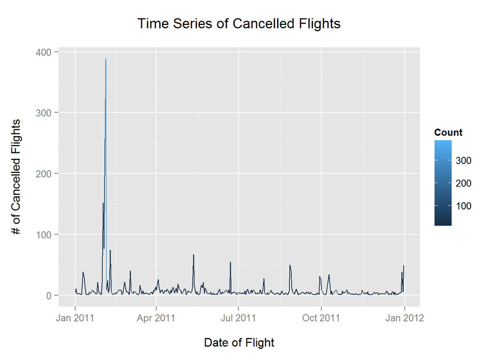

Looks like we have this huge spike in cancelled flights between Jan and Apr, so lets get the dates with the highest amount of cancelled flights.

```r
Most_Cancelled <- subset(x, x$Count > 100)
Most_Cancelled
```

```
##          Date Count
## 27 2011-02-01   152
## 29 2011-02-03   256
## 30 2011-02-04   388
```

```r
k <- subset(new_df, new_df$Date  >= 2011-02-01 | new_df$Date <= 2011-02-04)
k$CancellationCode <- ordered(k$CancellationCode, levels = CName)
```

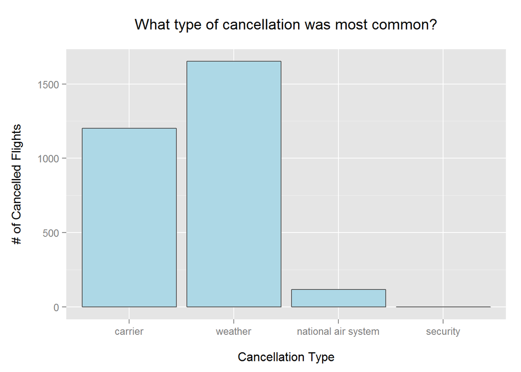